# Assignment 7 - Extra Credits: Practice dplyr and ggplot2

*How to do it?*:

- Open the Rmarkdown file of this assignment (link) in Rstudio.
- Right under each **question**, insert a code chunk (you can use the hotkey `Ctrl + Alt + I` to add a code chunk) and code the solution for the question.
- `Knit` the rmarkdown file (hotkey: `Ctrl + Alt + K`) to export an html.
- Publish the html file to your Githiub Page.

*Submission*: Submit the link on Github of the assignment to Canvas

1. Import the data at https://bryantstats.github.io/math421/data/ds_salaries.csv

   The data description can be found at https://www.kaggle.com/datasets/saurabhshahane/data-science-jobs-salaries

```r
library(tidyverse)
df <- read_csv("https://bryantstats.github.io/math421/data/ds_salaries.csv")
str(df)
```

```
## spc_tbl_ [607 × 11] (S3: spec_tbl_df/tbl_df/tbl/data.frame)
##  $ work_year         : num [1:607] 2020 2020 2020 2020 2020 2020 2020 2020 2020 2020 ...
##  $ experience_level  : chr [1:607] "MI" "SE" "SE" "MI" ...
##  $ employment_type   : chr [1:607] "FT" "FT" "FT" "FT" ...
##  $ job_title         : chr [1:607] "Data Scientist" "Machine Learning Scientist" "Big Data Engineer" "Product Data Analyst" ...
##  $ salary            : num [1:607] 70000 260000 85000 20000 150000 72000 190000 11000000 135000 125000 ...
##  $ salary_currency   : chr [1:607] "EUR" "USD" "GBP" "USD" ...
##  $ salary_in_usd     : num [1:607] 79833 260000 109024 20000 150000 ...
##  $ employee_residence: chr [1:607] "DE" "JP" "GB" "HN" ...
##  $ remote_ratio      : num [1:607] 0 0 50 0 50 100 100 50 100 50 ...
##  $ company_location  : chr [1:607] "DE" "JP" "GB" "HN" ...
##  $ company_size      : chr [1:607] "L" "S" "M" "S" ...
##  - attr(*, "spec")=
##   .. cols(
##   ..   work_year = col_double(),
##   ..   experience_level = col_character(),
##   ..   employment_type = col_character(),
##   ..   job_title = col_character(),
##   ..   salary = col_double(),
##   ..   salary_currency = col_character(),
##   ..   salary_in_usd = col_double(),
##   ..   employee_residence = col_character(),
##   ..   remote_ratio = col_double(),
##   ..   company_location = col_character(),
##   ..   company_size = col_character()
##   .. )
##  - attr(*, "problems")=<externalptr>
```

2. Is there any column that contains NAs?

```r
colSums(is.na(df))
```

```
##          work_year   experience_level    employment_type          job_title
##                  0                  0                  0                  0
##             salary    salary_currency      salary_in_usd employee_residence
##                  0                  0                  0                  0
##       remote_ratio   company_location       company_size
##                  0                  0                  0
```

**There are no columns that contain NAs.**

3. What is the most frequent job title in the data?

```r
df |> count(job_title) |> arrange(-n)
```

```
## # A tibble: 50 × 2
##    job_title                      n
##    <chr>                      <int>
##  1 Data Scientist               143
##  2 Data Engineer                132
##  3 Data Analyst                  97
##  4 Machine Learning Engineer     41
##  5 Research Scientist            16
##  6 Data Science Manager          12
##  7 Data Architect                11
##  8 Big Data Engineer              8
##  9 Machine Learning Scientist     8
## 10 AI Scientist                   7
## # ℹ 40 more rows
```

**“Data Scientist” is the most frequent job title in the data.**

4. Find the average salary data of the three most frequent job titles in the data.

```r
df |>
  filter(job_title %in% c("Data Scientist", "Data Engineer", "Data Analyst")) |>
  group_by(job_title) |>
  summarise(mean_salary = mean(salary_in_usd))
```

```
## # A tibble: 3 × 2
##   job_title      mean_salary
##   <chr>                <dbl>
## 1 Data Analyst        92893.
## 2 Data Engineer      112725
## 3 Data Scientist     108188.
```

5. What is the job title that have the highest average salary?

```r
df |>
  group_by(job_title) |>
  summarise(mean_salary = mean(salary_in_usd)) |>
  arrange(-mean_salary)
```

```
## # A tibble: 50 × 2
##    job_title                mean_salary
##    <chr>                          <dbl>
##  1 Data Analytics Lead          405000
##  2 Principal Data Engineer      328333.
##  3 Financial Data Analyst       275000
##  4 Principal Data Scientist     215242.
##  5 Director of Data Science     195074
##  6 Data Architect               177874.
##  7 Applied Data Scientist       175655
##  8 Analytics Engineer           175000
##  9 Data Specialist              165000
## 10 Head of Data                 160163.
## # ℹ 40 more rows
```

**“Data Analytics Lead” has the highest average salary.**

6. Which country gives the highest salary on average?

```r
df |>
  group_by(company_location) |>
  summarise(mean_salary = mean(salary_in_usd)) |>
  arrange(-mean_salary)
```

```
## # A tibble: 50 × 2
##    company_location mean_salary
##    <chr>                  <dbl>
##  1 RU                   157500
##  2 US                   144055.
##  3 NZ                   125000
##  4 IL                   119059
##  5 JP                   114127.
##  6 AU                   108043.
##  7 AE                   100000
##  8 DZ                   100000
##  9 IQ                   100000
## 10 CA                    99824.
## # ℹ 40 more rows
```

**Russia gives the highest average salary.**

7. Plot five meaningful plots. All plots should have title, caption, and appropriate labels.

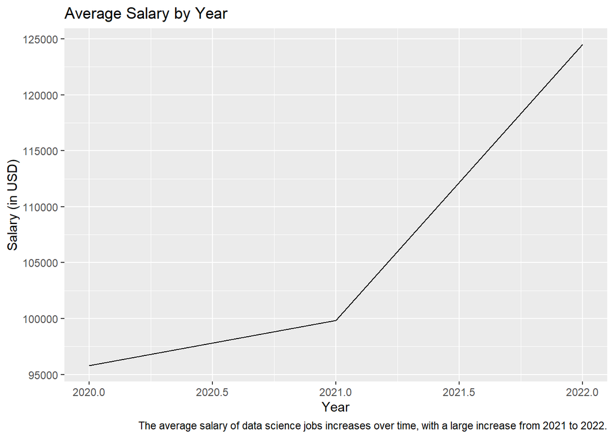

```r
# 1
df |>
  group_by(work_year) |>
  summarise(avg = mean(salary_in_usd)) |>
  ggplot() +
  geom_line(mapping = aes(x = work_year, y = avg)) +
  labs(x = 'Year',
       y = 'Salary (in USD)',
       title = 'Average Salary by Year',
       caption = 'The average salary of data science jobs increases over time, with a large increase from 2021 to 2022.')
```

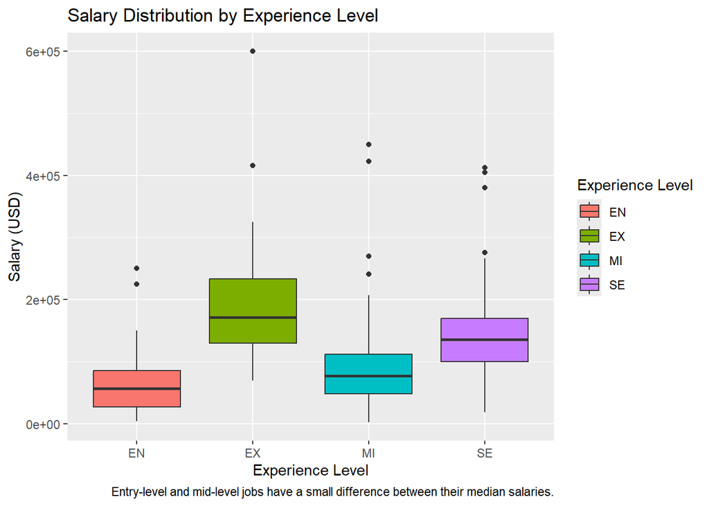

```r
# 2
df |>
  ggplot() +
  geom_boxplot(mapping = aes(x = experience_level, y = salary_in_usd, fill = experience_level)) +
  labs(x = 'Experience Level',
       y = 'Salary (USD)',
       fill = 'Experience Level',
       title = 'Salary Distribution by Experience Level',
       caption = 'Entry-level and mid-level jobs have a small difference between their median salaries.')
```

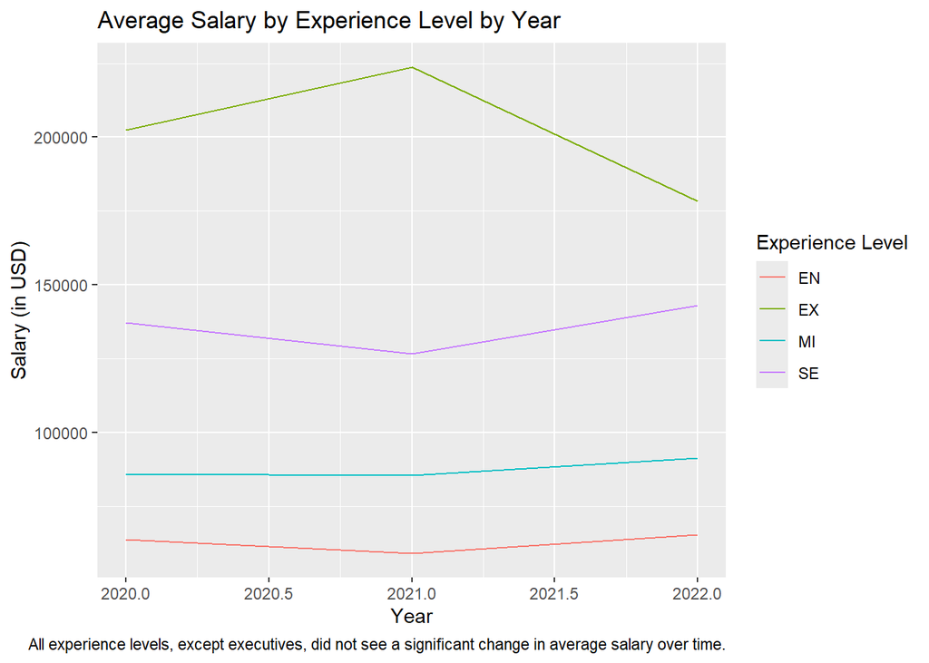

```r
# 3
df |>
  group_by(experience_level, work_year) |>
  summarise(avg = mean(salary_in_usd)) |>
  ggplot() +
  geom_line(mapping = aes(x = work_year, y = avg, color = experience_level)) +
  labs(x = 'Year',
       y = 'Salary (in USD)',
       color = 'Experience Level',
       title = 'Average Salary by Experience Level by Year',
       caption = 'All experience levels, except executives, did not see a significant change in average salary over time.')
```

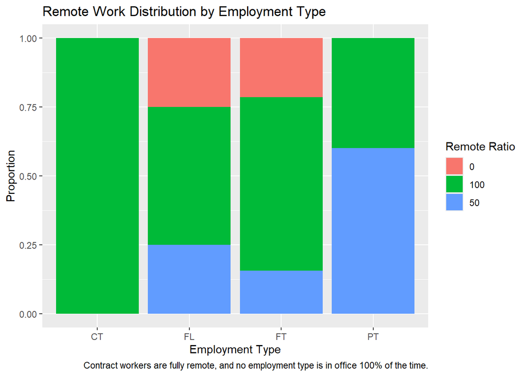

```r
# 4
df |>
  mutate(remote_ratio = as.character(remote_ratio)) |>
  ggplot() +
  geom_bar(mapping = aes(x = employment_type, fill = remote_ratio), position = 'fill') +
  labs(x = 'Employment Type',
       y = 'Proportion',
       fill = 'Remote Ratio',
       title = 'Remote Work Distribution by Employment Type',
       caption = 'Contract workers are fully remote, and no employment type is in office 100% of the time.')
```

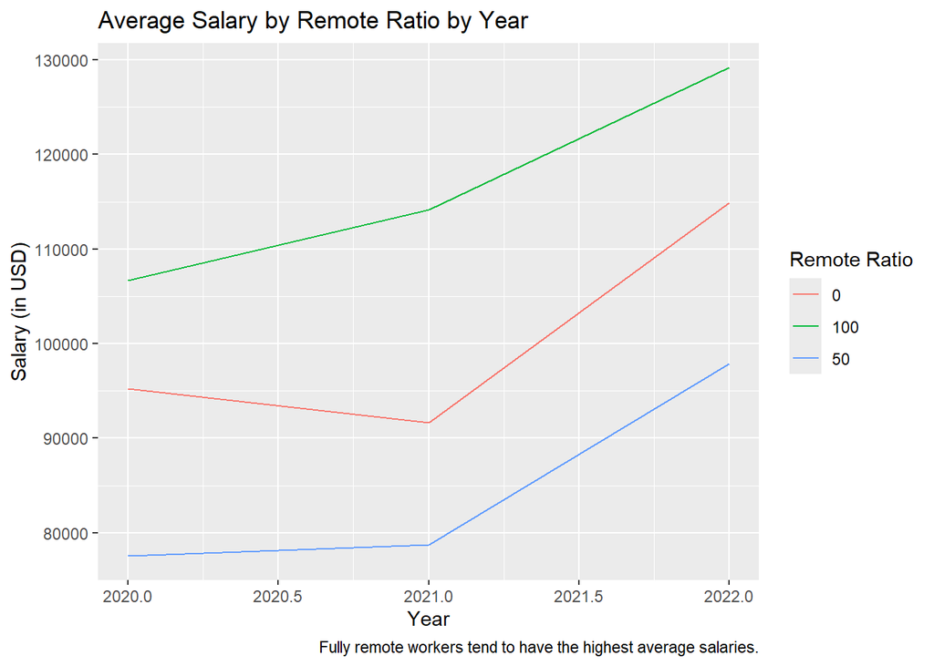

```r
# 5
df |>
  mutate(remote_ratio = as.character(remote_ratio)) |>
  group_by(remote_ratio, work_year) |>
  summarise(avg = mean(salary_in_usd)) |>
  ggplot() +
  geom_line(mapping = aes(x = work_year, y = avg, color = remote_ratio)) +
  labs(x = 'Year',
       y = 'Salary (in USD)',
       color = 'Remote Ratio',
       title = 'Average Salary by Remote Ratio by Year',
       caption = 'Fully remote workers tend to have the highest average salaries.')
```